# IBM Attrition Visualization Mini Project

Alan Qin

4/16/2020

# Dataset Introduction

# Fixing and Cleaning Data

```r
sum(is.na(ibm.data)) # Make sure no NA's in data
## 0
```

# List of Questions and Visualizations

## Question 1: How is average income affected by years of Education?

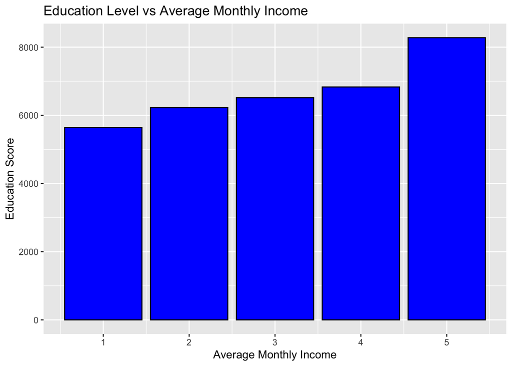

```r
ibm.income = ibm.data %>%
  group_by(Education) %>%
  summarise(average.income = mean(MonthlyIncome))
ggplot(data = ibm.income) +
  geom_bar(aes(x = Education, y = average.income),
           stat = 'identity',
           fill = 'blue',
           color = 'black') +
  labs(x = 'Average Monthly Income', y = 'Education Score') +
  ggtitle('Education Level vs Average Monthly Income')
```

In the IBM Attrition dataset, the education variable is measured with a number 1-5. 1 is below college, 2 is college, 3 is completion of a bachelors degree, 4 is the completion of a masters dgree, and 5 is the completion of a doctorate degree. As we can see from this plot, the average income increases as education increases. One of the most interesting things in this plot is that employees that have an education rating of 1 still make a decent amount of money compared to even a masters degree. Another interesting thing is that doctorate degrees earn much more than a masters degree.

## Question 2: How is average income affected by Education Field?

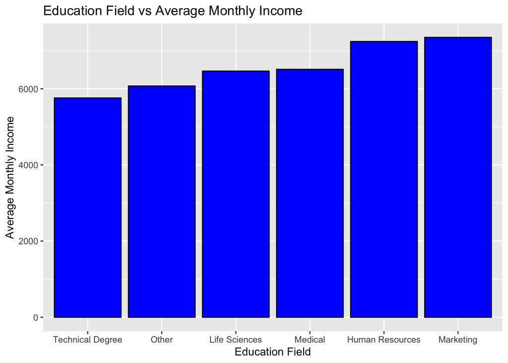

```r
ibm.edu = ibm.data %>% group_by(EducationField) %>% summarise(average.inc = mean(MonthlyIncome))
ggplot(data = ibm.edu) +
  geom_bar(aes(x = reorder(EducationField, average.inc), y = average.inc),
           stat = 'identity',
           fill = 'blue',
           color = 'black') +
  ggtitle('Education Field vs Average Monthly Income') +
  labs(x = 'Education Field', y = 'Average Monthly Income')
```

## Question 3: How does age affect income?

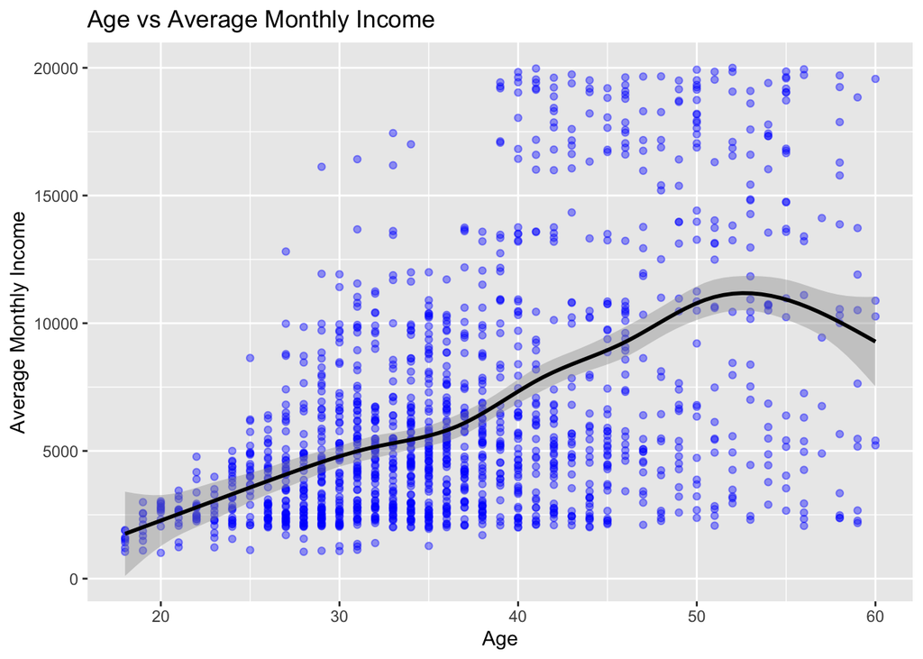

```r
ggplot(data = ibm.data) +
  geom_point(aes(x = Age, y = MonthlyIncome), color = 'blue', alpha = .4) +
  ggtitle('Age vs Average Monthly Income') +
  labs(x = "Age", y = 'Average Monthly Income') +
  geom_smooth(aes(x = Age, y = MonthlyIncome), color = 'black')
```

As you can see from this plot, the average monthly income for employees increases as employees get older from ages 18 to around 52. After 52, the average monthly income for employees decreases. I think this situation happens at every company. After around 50, income decreases because employees are not as sharp as they are when they were younger.

## Question 4: Job role effect on income?

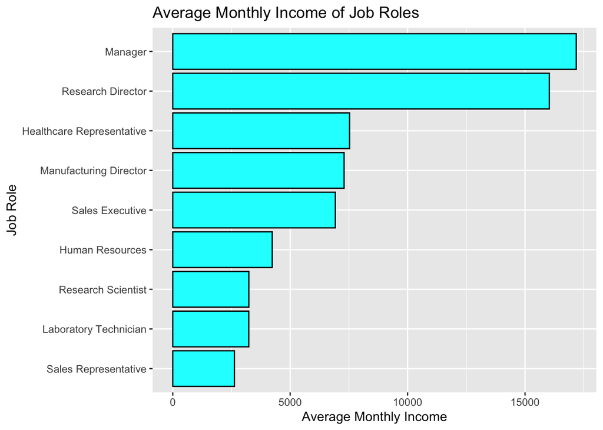

```r
ibm.job = ibm.data %>% group_by(JobRole) %>% summarise(avgInc = mean(MonthlyIncome))
x = ibm.job %>% arrange(desc(avgInc))
ggplot(data = x, aes(x = reorder(JobRole, avgInc), y = avgInc)) +
  geom_bar(stat = 'identity', color = 'black', fill = 'cyan') +
  coord_flip() +
  ggtitle('Average Monthly Income of Job Roles') +
  labs(y = 'Average Monthly Income', x = 'Job Role')
```

In this plot, I believe there weren’t too many suprises and the results were relatively predictable. The one thing that suprised me was the fact that Healthcare Representatives made more money than Manufacturing Directors. This is because I assumed that managers or directors would make more money than your average worker at the company.

## Question 5: How happy are employees?

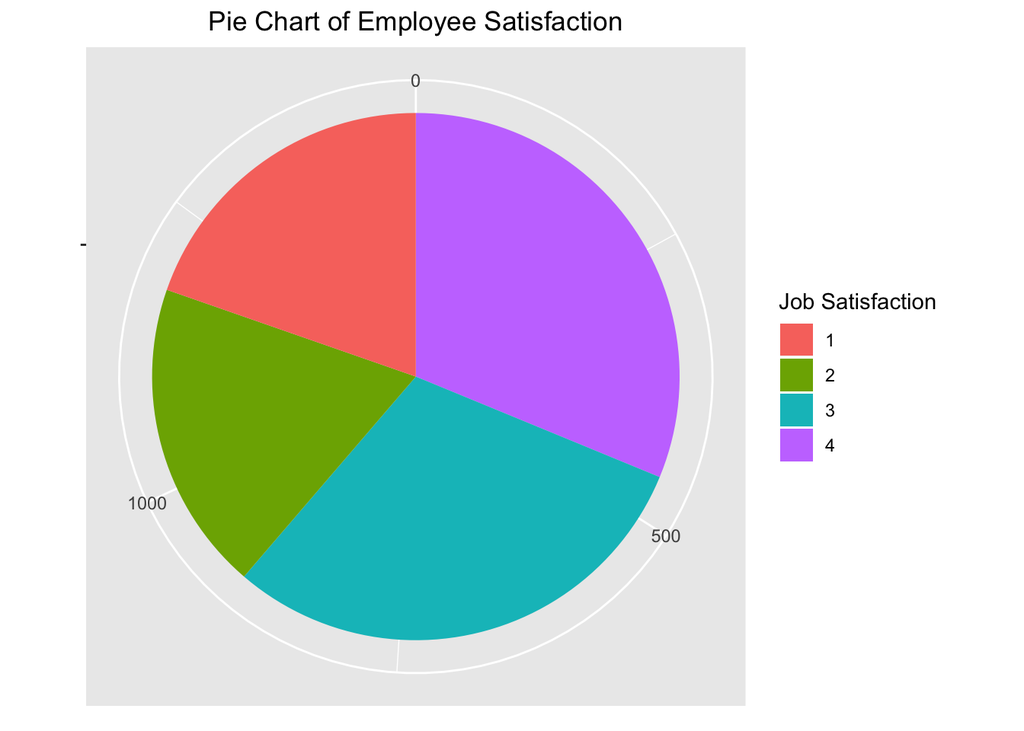

```r
pie = ggplot(ibm.data, aes(x = "", fill = as.factor(JobSatisfaction))) +
  geom_bar(width = 1) +
  theme(axis.line = element_blank(), plot.title = element_text(hjust = .5)) +
  labs(fill = 'Job Satisfaction', x=NULL, y = NULL) +
  ggtitle('Pie Chart of Employee Satisfaction')
pie + coord_polar(theta = 'y', start =0)
```

This plot is very self explanatory in the fact that it shows that the proportion of employees that are satisfied with their job. The levels for job satisifcation are 1 is low, 2 is medium, 3 is high, and 4 is very high. As you can see, the majority of employees reported a score of 2, 3, or 4 which means that a high percentage of people are satisified with their jobs.